# Analisis Metode Pemulusan (Smoothing) Data Time Series Bitcoin

Bagian Data: Zul Padli Yanshah (Periode 800 - 1000)

Zul Padli Yanshah

30 August 2026

# 1 Pendahuluan

Tugas kelompok meminta setiap anggota menerapkan metode pemulusan (*smoothing*) pada bagiannya masing-masing dari satu data *time series* dengan panjang total ≥ 500 periode, lalu membandingkan kinerja beberapa metode menggunakan metrik akurasi (SSE, MSE, RMSE, MAPE) dan menentukan metode terbaik.

Data yang digunakan adalah **harga penutupan Bitcoin (USD)** harian. Data total memiliki 1000 periode dan dibagi rata ke 5 anggota kelompok. Bagian yang menjadi tanggung jawab **Zul Padli Yanshah** adalah **periode 800 sampai 1000 (201 observasi)**.

# 2 Persiapan Library dan Data

```r
library(forecast)   # ses(), holt(), hw(), accuracy()
library(ggplot2)    # visualisasi
```

```r
# Baca data. File CSV diasumsikan berada satu folder dengan script ini.
df <- read.csv("Bitcoin_1000_Period_clean_zfd.csv", stringsAsFactors = FALSE)

# Pastikan data terurut berdasarkan Period
df <- df[order(df$Period), ]

# Ambil bagian Zul Padli Yanshah: Period 800 - 1000
df_zul <- subset(df, Period >= 800 & Period <= 1000)

cat("Jumlah observasi bagian Zul Padli Yanshah :", nrow(df_zul), "\n")
```

```
## Jumlah observasi bagian Zul Padli Yanshah : 201
```

```r
cat("Rentang periode              :", min(df_zul$Period), "-", max(df_zul$Period), "\n")
```

```
## Rentang periode              : 800 - 1000
```

```r
head(df_zul)
```

```
##        Date Period    Price
## 1 10/2/2026    800 68793.96
## 2 11/2/2026    801 66991.97
## 3 12/2/2026    802 66221.84
## 4  13-02-26    803 68857.84
## 5  14-02-26    804 69767.62
## 6  15-02-26    805 68788.19
```

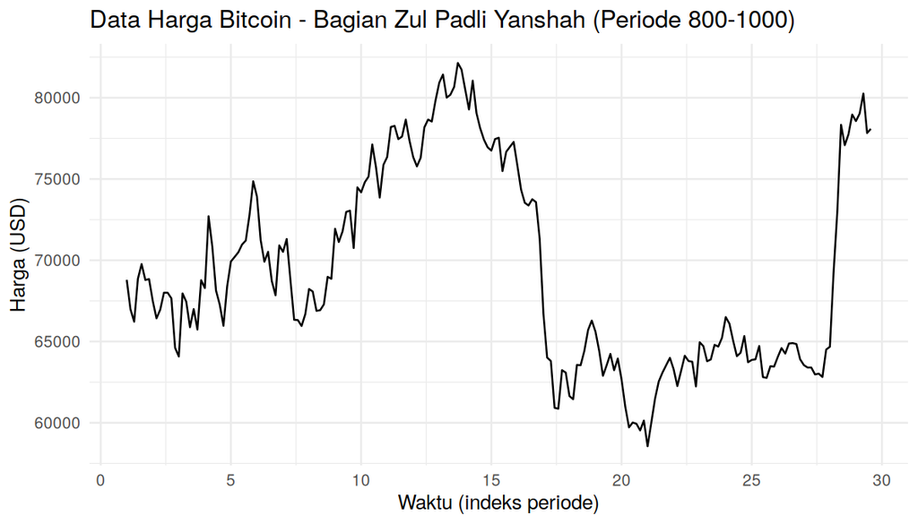

```r
# Ubah menjadi objek time series.
# frequency = 7 digunakan agar metode Holt-Winters (musiman) dapat diterapkan
# (siklus mingguan), sedangkan metode lain (SMA/DMA/SES/DES) tidak terpengaruh
# oleh nilai frequency ini.
harga_ts <- ts(df_zul$Price, frequency = 7)

autoplot(harga_ts) +
  labs(title = "Data Harga Bitcoin - Bagian Zul Padli Yanshah (Periode 800-1000)",
       x = "Waktu (indeks periode)", y = "Harga (USD)") +
  theme_minimal()
```

Dari plot terlihat data berfluktuasi naik-turun dengan **tren** yang cenderung meningkat pada bagian akhir periode, namun tidak menunjukkan pola musiman yang kuat dan jelas.

# 3 Fungsi Metrik Akurasi

Empat metrik akurasi dihitung untuk setiap metode: **SSE, MSE, RMSE, MAPE**.

```r
akurasi <- function(actual, fitted) {
  idx <- !is.na(fitted) & !is.na(actual)
  e   <- actual[idx] - fitted[idx]
  sse  <- sum(e^2)
  mse  <- mean(e^2)
  rmse <- sqrt(mse)
  mape <- mean(abs(e / actual[idx])) * 100
  c(SSE = sse, MSE = mse, RMSE = rmse, MAPE = mape)
}
```

# 4 Penerapan Metode Pemulusan

## 4.1 Simple Moving Average (SMA)

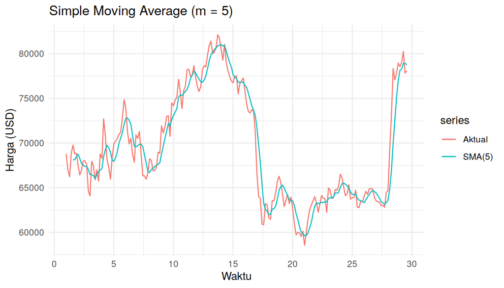

```r
m <- 5  # orde bergerak
sma_fit <- stats::filter(harga_ts, rep(1/m, m), sides = 1)

autoplot(harga_ts, series = "Aktual") +
  autolayer(ts(sma_fit, start = start(harga_ts), frequency = 7), series = paste0("SMA(", m, ")")) +
  labs(title = paste0("Simple Moving Average (m = ", m, ")"), y = "Harga (USD)", x = "Waktu") +
  theme_minimal()
```

## 4.2 Double Moving Average (DMA)

DMA diperoleh dengan menghitung rata-rata bergerak dari hasil SMA (rata-rata bergerak tingkat dua), lalu digunakan untuk menghitung penyesuaian tren.

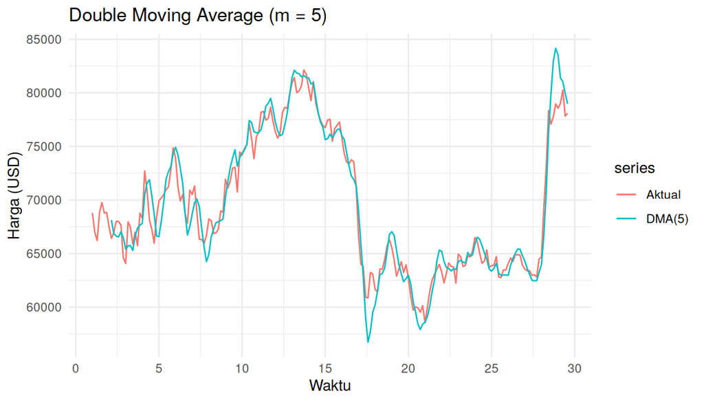

```r
sma1 <- stats::filter(harga_ts, rep(1/m, m), sides = 1)
sma2 <- stats::filter(sma1, rep(1/m, m), sides = 1)

a_t <- 2 * sma1 - sma2
b_t <- (2 / (m - 1)) * (sma1 - sma2)
dma_fit <- a_t + b_t

autoplot(harga_ts, series = "Aktual") +
  autolayer(ts(dma_fit, start = start(harga_ts), frequency = 7), series = paste0("DMA(", m, ")")) +
  labs(title = paste0("Double Moving Average (m = ", m, ")"), y = "Harga (USD)", x = "Waktu") +
  theme_minimal()
```

## 4.3 Single Exponential Smoothing (SES)

```r
ses_model <- ses(harga_ts, h = 10)
summary(ses_model)
```

```
##
## Forecast method: Simple exponential smoothing
##
## Model Information:
## Simple exponential smoothing
##
## Call:
##  ses(y = harga_ts, h = 10)
##
##   Smoothing parameters:
##     alpha = 0.9973
##
##   Initial states:
##     l = 68640.0647
##
##   sigma:  1460.526
##
##      AIC     AICc      BIC
## 3999.148 3999.270 4009.058
##
## Error measures:
##                    ME     RMSE      MAE        MPE     MAPE      MASE      ACF1
## Training set 47.11772 1453.241 1073.726 0.04232764 1.547642 0.3567658 0.1018904
##
## Forecasts:
##          Point Forecast    Lo 80    Hi 80    Lo 95    Hi 95
## 29.71429        78085.1 76213.36 79956.84 75222.52 80947.68
## 29.85714        78085.1 75441.64 80728.56 74042.28 82127.92
## 30.00000        78085.1 74849.00 81321.20 73135.91 83034.29
## 30.14286        78085.1 74349.22 81820.98 72371.56 83798.64
## 30.28571        78085.1 73908.82 82261.38 71698.03 84472.17
## 30.42857        78085.1 73510.63 82659.57 71089.05 85081.15
## 30.57143        78085.1 73144.43 83025.77 70528.99 85641.21
## 30.71429        78085.1 72803.56 83366.64 70007.67 86162.53
## 30.85714        78085.1 72483.39 83686.81 69518.02 86652.18
## 31.00000        78085.1 72180.55 83989.65 69054.88 87115.32
```

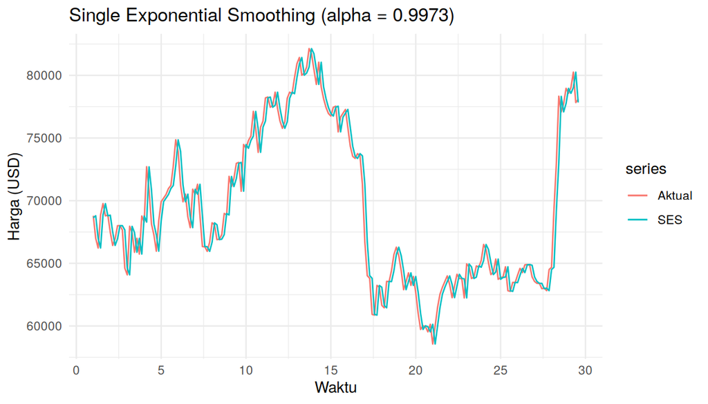

```r
autoplot(harga_ts, series = "Aktual") +
  autolayer(fitted(ses_model), series = "SES") +
  labs(title = paste0("Single Exponential Smoothing (alpha = ",
                       round(ses_model$model$par["alpha"], 4), ")"),
       y = "Harga (USD)", x = "Waktu") +
  theme_minimal()
```

## 4.4 Double Exponential Smoothing / Holt’s Linear Trend (DES)

```r
des_model <- holt(harga_ts, h = 10)
summary(des_model)
```

```
##
## Forecast method: Holt's method
##
## Model Information:
## Holt's method
##
## Call:
##  holt(y = harga_ts, h = 10)
##
##   Smoothing parameters:
##     alpha = 0.9999
##     beta  = 1e-04
##
##   Initial states:
##     l = 68418.3581
##     b = -33.7537
##
##   sigma:  1469.286
##
##      AIC     AICc      BIC
## 4003.522 4003.830 4020.038
##
## Error measures:
##                    ME     RMSE      MAE        MPE     MAPE      MASE
## Training set 81.44006 1454.593 1075.671 0.09237001 1.549814 0.3574123
##                    ACF1
## Training set 0.09835414
##
## Forecasts:
##          Point Forecast    Lo 80    Hi 80    Lo 95    Hi 95
## 29.71429       78053.63 76170.66 79936.60 75173.88 80933.38
## 29.85714       78021.52 75358.60 80684.43 73948.94 82094.09
## 30.00000       77989.40 74727.90 81250.90 73001.36 82977.44
## 30.14286       77957.29 74191.07 81723.50 72197.36 83717.22
## 30.28571       77925.17 73714.22 82136.12 71485.08 84365.26
## 30.42857       77893.06 73279.98 82506.13 70837.97 84948.15
## 30.57143       77860.94 72878.01 82843.87 70240.21 85481.68
## 30.71429       77828.83 72501.59 83156.06 69681.53 85976.13
## 30.85714       77796.71 72146.05 83447.37 69154.78 86438.65
## 31.00000       77764.60 71807.99 83721.21 68654.75 86874.45
```

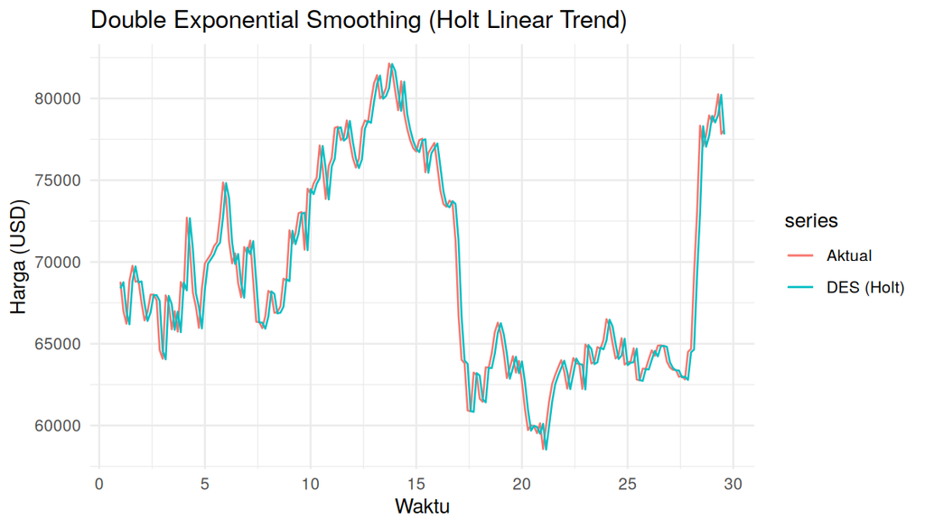

```r
autoplot(harga_ts, series = "Aktual") +
  autolayer(fitted(des_model), series = "DES (Holt)") +
  labs(title = "Double Exponential Smoothing (Holt Linear Trend)",
       y = "Harga (USD)", x = "Waktu") +
  theme_minimal()
```

## 4.5 Holt-Winters (Triple Exponential Smoothing)

```r
hw_model <- hw(harga_ts, h = 14, seasonal = "additive")
summary(hw_model)
```

```
##
## Forecast method: Holt-Winters' additive method
##
## Model Information:
## Holt-Winters' additive method
##
## Call:
##  hw(y = harga_ts, h = 14, seasonal = "additive")
##
##   Smoothing parameters:
##     alpha = 0.9999
##     beta  = 1e-04
##     gamma = 1e-04
##
##   Initial states:
##     l = 68671.0461
##     b = 69.5961
##     s = 252.7168 -128.3181 -86.3195 -103.3556 -16.2548 100.4308
##            -18.8995
##
##   sigma:  1481.266
##
##      AIC     AICc      BIC
## 4013.514 4015.174 4053.154
##
## Error measures:
##                     ME     RMSE      MAE        MPE     MAPE      MASE
## Training set -21.69444 1440.164 1060.976 -0.0572322 1.531125 0.3525295
##                   ACF1
## Training set 0.1112293
##
## Forecasts:
##          Point Forecast    Lo 80    Hi 80    Lo 95    Hi 95
## 29.71429       78112.95 76214.63 80011.26 75209.72 81016.17
## 29.85714       78563.17 75878.54 81247.80 74457.39 82668.95
## 30.00000       78360.64 75072.55 81648.74 73331.94 83389.35
## 30.14286       78548.93 74752.01 82345.84 72742.04 84355.81
## 30.28571       78501.70 74256.42 82746.97 72009.11 84994.28
## 30.42857       78483.65 73832.96 83134.33 71371.04 85596.25
## 30.57143       78569.89 73546.34 83593.44 70887.03 86252.75
## 30.71429       78597.06 73226.33 83967.79 70383.24 86810.88
## 30.85714       79047.29 73350.50 84744.07 70334.80 87759.77
## 31.00000       78844.76 72839.53 84849.99 69660.56 88028.96
## 31.14286       79033.04 72734.40 85331.68 69400.10 88665.98
## 31.28571       78985.81 72406.78 85564.85 68924.05 89047.58
## 31.42857       78967.76 72119.75 85815.77 68494.63 89440.89
## 31.57143       79054.01 71947.14 86160.87 68185.00 89923.01
```

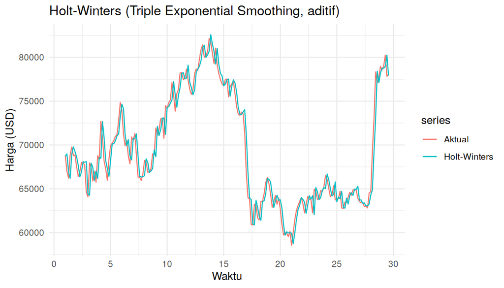

```r
autoplot(harga_ts, series = "Aktual") +
  autolayer(fitted(hw_model), series = "Holt-Winters") +
  labs(title = "Holt-Winters (Triple Exponential Smoothing, aditif)",
       y = "Harga (USD)", x = "Waktu") +
  theme_minimal()
```

# 5 Perbandingan Kinerja Metode

```r
hasil <- rbind(
  SMA          = akurasi(as.numeric(harga_ts), as.numeric(sma_fit)),
  DMA          = akurasi(as.numeric(harga_ts), as.numeric(dma_fit)),
  SES          = akurasi(as.numeric(harga_ts), as.numeric(fitted(ses_model))),
  DES          = akurasi(as.numeric(harga_ts), as.numeric(fitted(des_model))),
  Holt_Winters = akurasi(as.numeric(harga_ts), as.numeric(fitted(hw_model)))
)

hasil_df <- as.data.frame(round(hasil, 3))
knitr::kable(hasil_df, caption = "Perbandingan SSE, MSE, RMSE, dan MAPE tiap metode")
```

Perbandingan SSE, MSE, RMSE, dan MAPE tiap metode

|  | SSE | MSE | RMSE | MAPE |
| --- | --- | --- | --- | --- |
| SMA | 563885331 | 2862362 | 1691.852 | 1.790 |
| DMA | 474723570 | 2459708 | 1568.346 | 1.706 |
| SES | 424493867 | 2111910 | 1453.241 | 1.548 |
| DES | 425284104 | 2115841 | 1454.593 | 1.550 |
| Holt_Winters | 416888271 | 2074071 | 1440.164 | 1.531 |

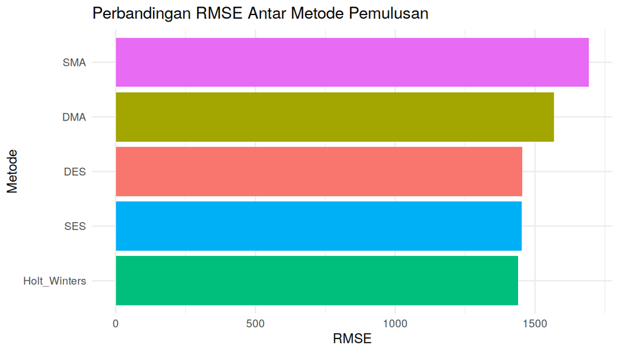

```r
hasil_df$Metode <- rownames(hasil_df)

ggplot(hasil_df, aes(x = reorder(Metode, RMSE), y = RMSE, fill = Metode)) +
  geom_col(show.legend = FALSE) +
  coord_flip() +
  labs(title = "Perbandingan RMSE Antar Metode Pemulusan",
       x = "Metode", y = "RMSE") +
  theme_minimal()
```

```r
metode_terbaik <- hasil_df$Metode[which.min(hasil_df$RMSE)]
cat("Metode dengan RMSE terkecil:", metode_terbaik, "\n")
```

```
## Metode dengan RMSE terkecil: Holt_Winters
```

# 6 Kesimpulan

Ringkasan Akurasi (diurutkan dari terbaik)

|  | SSE | MSE | RMSE | MAPE |
| --- | --- | --- | --- | --- |
| Holt_Winters | 416888271 | 2074071 | 1440.164 | 1.531 |
| SES | 424493867 | 2111910 | 1453.241 | 1.548 |
| DES | 425284104 | 2115841 | 1454.593 | 1.550 |
| DMA | 474723570 | 2459708 | 1568.346 | 1.706 |
| SMA | 563885331 | 2862362 | 1691.852 | 1.790 |

Berdasarkan hasil perbandingan di atas, metode **Holt_Winters** memberikan nilai SSE, MSE, RMSE, dan MAPE yang **paling kecil** dibandingkan metode lain, sehingga dipilih sebagai metode pemulusan terbaik untuk bagian data Zul Padli Yanshah (periode 800-1000).

Secara umum:

Metode terbaik yang terpilih (**Holt_Winters**) merupakan metode yang paling mampu mengikuti pergerakan harga Bitcoin pada rentang periode 800-1000 dengan galat (error) paling kecil di antara kelima metode yang diuji.